# 1 Learning objectives

1. You can visualize relationships between two numerical variables using `geom_line()`.
2. You can add a layer of points to a linegraph with `geom_point()`.
3. You can use the `labs()` function to edit titles, subtitles, and captions.

# 2 5NG #2: Linegraphs

The next of the five named graphs are linegraphs. Linegraphs show the relationship between two numerical variables when the variable on the x-axis, also called the *explanatory* variable, is of a sequential nature. In other words, there is an inherent ordering to the variable.

The most common examples of linegraphs have some notion of time on the x-axis: hours, days, weeks, years, etc. Since time is sequential, we connect consecutive observations of the variable on the y-axis with a line. Linegraphs that have some notion of time on the *x*-axis are also called *time series* plots.

# 3 The `gapminder` data frame

Our data for this lesson comes from the [gapminder](http://www.gapminder.org/data/) dataset, which we encountered previously in Lesson 3.

```r
# Load gapminder data frame from the gapminder package
data(gapminder, package="gapminder")

gapminder
```

| country | continent | year | lifeExp | pop | gdpPercap |
| --- | --- | --- | --- | --- | --- |
| Afghanistan | Asia | 1952 | 28.801 | 8425333 | 779.4453145 |
| Afghanistan | Asia | 1957 | 30.332 | 9240934 | 820.8530296 |
| Afghanistan | Asia | 1962 | 31.997 | 10267083 | 853.10071 |
| Afghanistan | Asia | 1967 | 34.02 | 11537966 | 836.1971382 |
| Afghanistan | Asia | 1972 | 36.088 | 13079460 | 739.9811058 |
| Afghanistan | Asia | 1977 | 38.438 | 14880372 | 786.11336 |
| Afghanistan | Asia | 1982 | 39.854 | 12881816 | 978.0114388 |
| Afghanistan | Asia | 1987 | 40.822 | 13867957 | 852.3959448 |
| Afghanistan | Asia | 1992 | 41.674 | 16317921 | 649.3413952 |
| Afghanistan | Asia | 1997 | 41.763 | 22227415 | 635.341351 |

[output cut: 1694 more lines]

Let’s say we want to visualize the relationship between time (`year`) and life expectancy (`lifeExp`) in the United States between 1952 and 2007. Before we make the plot of US life expectancy over time, we need to create a new data frame with only the data we want to plot:

```r
# Select US cases
gapminder_US <- dplyr::filter(gapminder,
                              country == "United States")

gapminder_US
```

| country | continent | year | lifeExp | pop | gdpPercap |
| --- | --- | --- | --- | --- | --- |
| United States | Americas | 1952 | 68.44 | 157553000 | 13990.48208 |
| United States | Americas | 1957 | 69.49 | 171984000 | 14847.12712 |
| United States | Americas | 1962 | 70.21 | 186538000 | 16173.14586 |
| United States | Americas | 1967 | 70.76 | 198712000 | 19530.36557 |
| United States | Americas | 1972 | 71.34 | 209896000 | 21806.03594 |
| United States | Americas | 1977 | 73.38 | 220239000 | 24072.63213 |
| United States | Americas | 1982 | 74.65 | 232187835 | 25009.55914 |
| United States | Americas | 1987 | 75.02 | 242803533 | 29884.35041 |
| United States | Americas | 1992 | 76.09 | 256894189 | 32003.93224 |
| United States | Americas | 1997 | 76.81 | 272911760 | 35767.43303 |

[output cut: 2 more lines]

The code above is a preview of Chapter 4 on data wrangling using the `dplyr` package. Data wrangling is the process of transforming and modifying existing data with the intent of making it more appropriate for analysis purposes. For example, this code segments used the `filter()` function to create a new data frame (`gapminder_US`) by choosing only a subset of rows of original `gapminder` data frame (only those that have “United States” in the `country` column). In the next chapter, we’ll formally introduce the `filter()` and other data wrangling functions.

# 4 Linegraphs via `geom_line`

Now we’re ready to feed the `gapminder_US` data frame to `ggplot()`, mapping **time** in years on the horizontal *x* axis and **life expectancy** on the vertical *y* axis.

We can visualize this time series data by using `geom_line()` to create a linegraph, instead of using `geom_point()` like we used previously to create scatterplots:

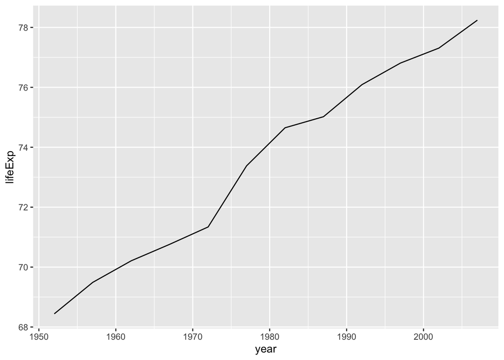

```r
# simple linegraph
ggplot(gapminder_US,
       mapping = aes(x = year,
                     y = lifeExp)) +
  geom_line()
```

Much as with the `ggplot()` code that created the scatterplot of age and viral load with `geom_point()`, let’s break down this code piece-by-piece in terms of the grammar of graphics:

Within the `ggplot()` function call, we specify two of the components of the grammar of graphics as arguments:

1. The `data` to be the `gapminder_US` data frame by setting `data = gapminder_US`.
2. The `aes`thetic `mapping` by setting `mapping = aes(x = year, y = lifeExp)`. Specifically, the variable `year` maps to the `x` position aesthetic, while the variable `lifeExp` maps to the `y` position aesthetic.

After telling R which data and aesthetic mappings we wanted to plot we then added the third essential component, the `geom`etric object using the `+` sign, In this case, the geometric object was set to lines using `geom_line()`.

- Create a time series plot of the GPD per capita (`gdpPercap`) recorded in the `gapminder_US` data frame by using `geom_line()` to create a linegraph.

## 4.1 Line customization

The color, line width and line type of the linegraph can be customized making use of `color`, `lwd` and `linetype` arguments.

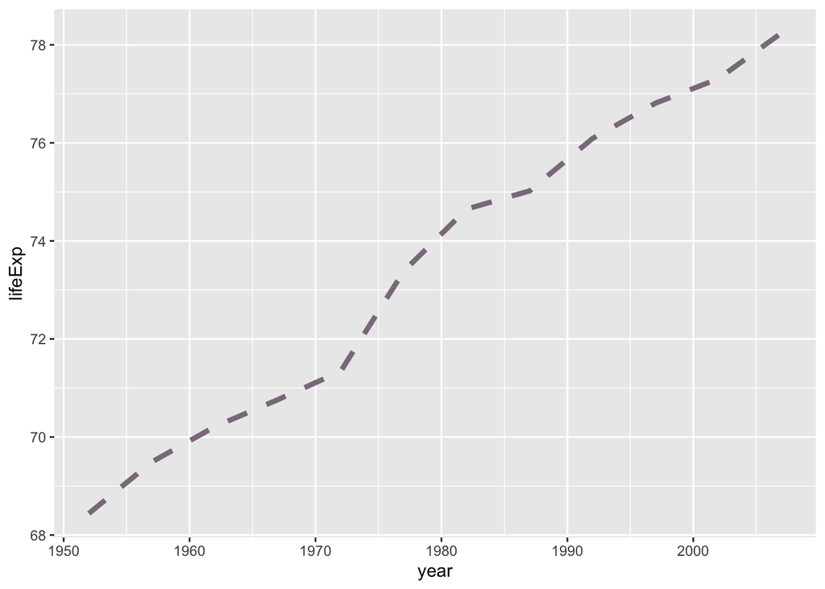

```r
# simple linegraph
ggplot(gapminder_US,
       mapping = aes(x = year,
                     y = lifeExp)) +
  geom_line(colour = "thistle4",
            lwd = 1.5,
            linetype = "dashed")
```

Line type can be specified using a name, as shown above, or with an integer. Valid line types can be set using a human readable character string: `"blank"`, `"solid"`, `"dashed"`, `"dotted"`, `"dotdash"`, `"longdash"`, and `"twodash"` are all understood by `linetype` (or `lty`).

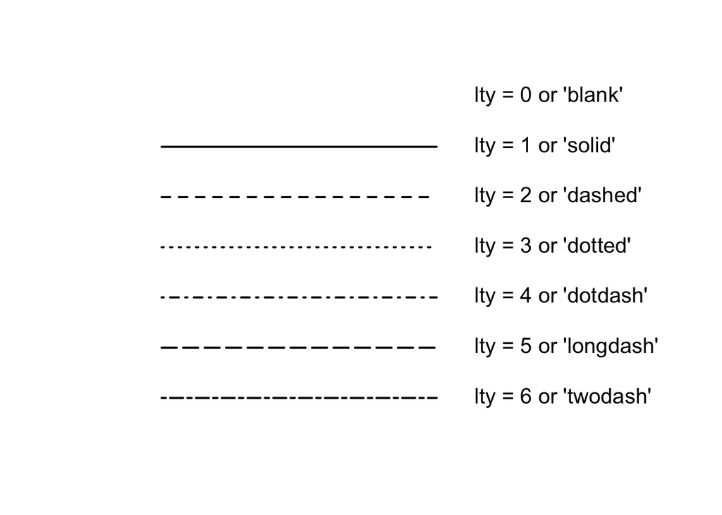

It is hard to read individual values in the linegraphs above. In the next plot, we’ll add points to make this clearer.

# 5 Combining compatible geoms

As long as the geoms are compatible, we can layer them on top of one another to further customize a graph.

For example, we can add points to our linegraph using the `+` sign to add a second `geom` layer with `geom_point()`:

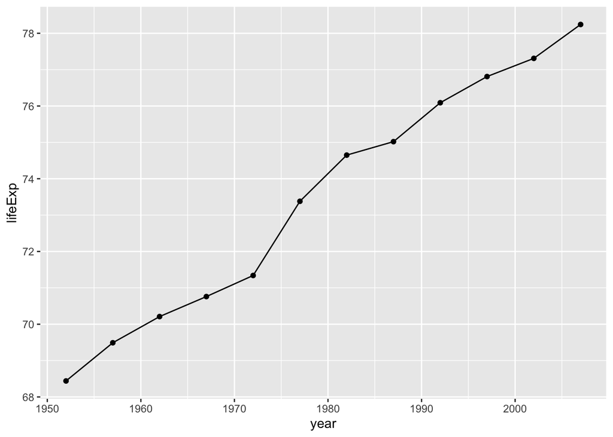

```r
# linegraph with points
# and improved aesthetics
ggplot(gapminder_US,
       aes(x = year,
           y = lifeExp)) +
  geom_line() +
  geom_point()
```

We can create a more attractive plot by customizing the size and color of our geoms.

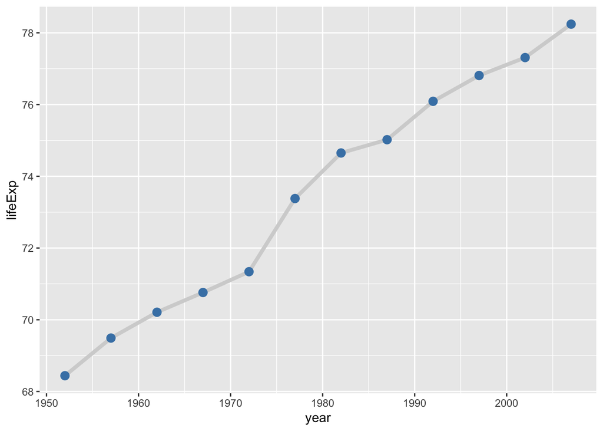

```r
# linegraph with points
# and improved aesthetics
ggplot(gapminder_US,
       aes(x = year,
           y = lifeExp)) +
  geom_line(size = 1.5,
            color = "lightgrey") +
  geom_point(size = 3,
             color = "steelblue")
```

- Building on the code above, visualize the relationship between time the GPD per capita `gapminder_US` data frame with both points and lines. Change the color of the points as desired.
- As an added challenge, map a third variable, population (`pop`), onto the size of the points.

# 6 Labeling with `labs()`

So far, we haven’t added or customized text in plots. Plots need to be informative. The reader should see the story behind the data analysis just by looking at the graph without referring additional documentation. Hence, graphs need good labels. You can add labels to a plot with the `labs()` function. Arguments we can specify with the `labs()` function include:

- `x`: Rename *x*-axis
- `y`: Rename *y*-axis
- `title`: Change or add a title
- `subtitle`: Add subtitle below the title
- `caption`: Add caption below the graph

We add `labs()` to the plot using a `+` sign. For example, we can change out axis titles and add a title, subtitle, and caption to the plot:

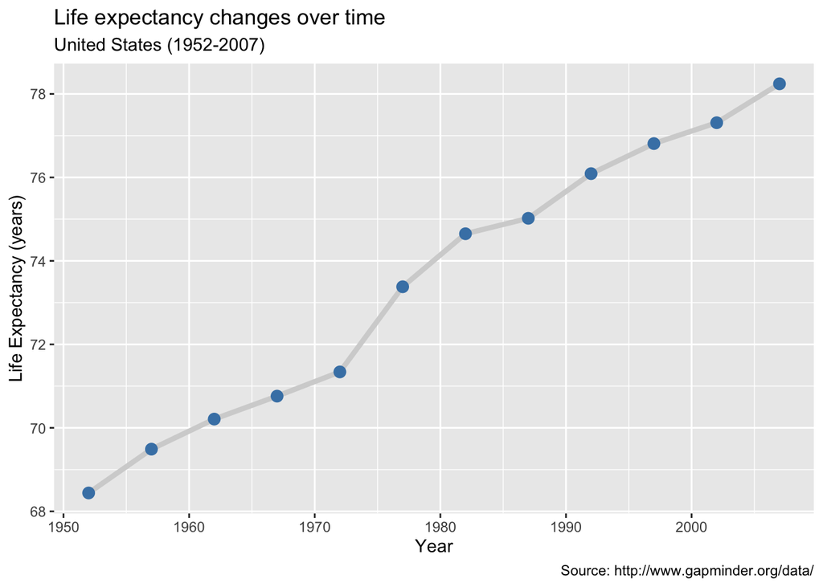

```r
# linegraph with improved labeling
ggplot(gapminder_US,
       aes(x = year,
           y = lifeExp)) +
  geom_line(size = 1.5,
            color = "lightgrey") +
  geom_point(size = 3,
             color = "steelblue") +
  labs(y = "Life Expectancy (years)",
       x = "Year",
       title = "Life expectancy changes over time",
       subtitle = "United States (1952-2007)",
       caption = "Source: http://www.gapminder.org/data/")
```

# 7 Faceting with `facet_wrap()`

When we **facet** graphs, we split them up into **multiple panels**, one for each level of a third variable. Each panel contains a subset of the data. It is easiest to understand this with an example. Let’s say we interested in looking at how the changes life expectancy differed between countries in the Americas. We can use `facet_wrap()` to separate time series plots for each country.

First let’s subset the `gapminder` data frame to only include data for which the `contintent` is “Americas”.

```r
# Select the Americas data
gap_americas <- dplyr::filter(gapminder,
                              continent == "Americas")
gap_americas
```

| country | continent | year | lifeExp | pop | gdpPercap |
| --- | --- | --- | --- | --- | --- |
| Argentina | Americas | 1952 | 62.485 | 17876956 | 5911.315053 |
| Argentina | Americas | 1957 | 64.399 | 19610538 | 6856.856212 |
| Argentina | Americas | 1962 | 65.142 | 21283783 | 7133.166023 |
| Argentina | Americas | 1967 | 65.634 | 22934225 | 8052.953021 |
| Argentina | Americas | 1972 | 67.065 | 24779799 | 9443.038526 |
| Argentina | Americas | 1977 | 68.481 | 26983828 | 10079.02674 |
| Argentina | Americas | 1982 | 69.942 | 29341374 | 8997.897412 |
| Argentina | Americas | 1987 | 70.774 | 31620918 | 9139.671389 |
| Argentina | Americas | 1992 | 71.868 | 33958947 | 9308.41871 |
| Argentina | Americas | 1997 | 73.275 | 36203463 | 10967.28195 |

[output cut: 290 more lines]

Now that the data is ready, we can plot separate linegraphs for each `country` in the Americas. We do this by adding `facet_wrap(~country)`. The `~` is a “tilde” and can generally be found on the key next to the “1” key on most keyboards.

The tilde is required and you’ll receive the error `Error in as.quoted(facets) : object 'country' not found` if you don’t include it in `facet_wrap()`.

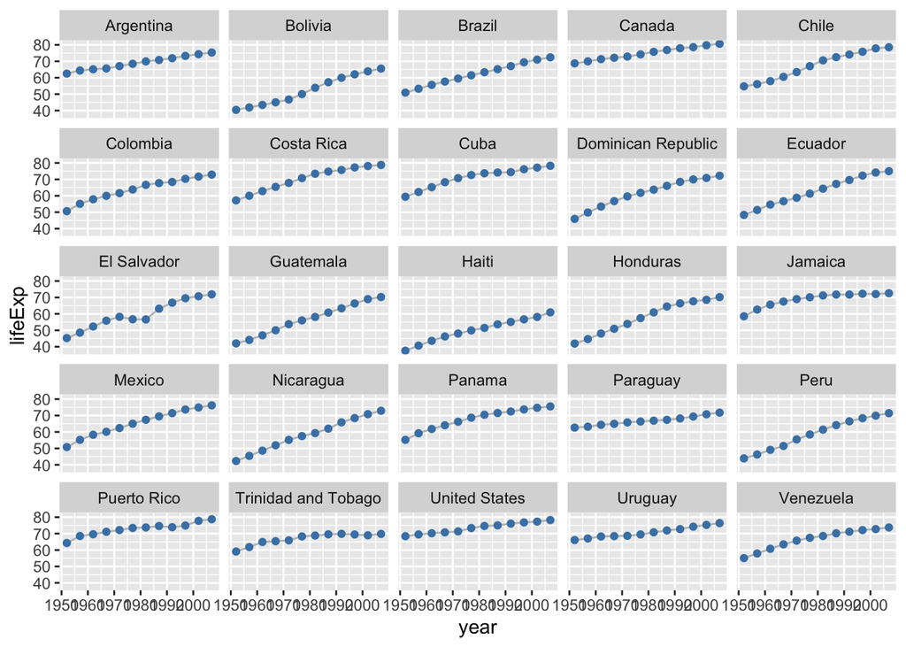

```r
# Plot life expectancy by year separately for each country in the Americas

ggplot(gap_americas, aes(x=year, y = lifeExp)) +
  geom_line(color = "grey") +
  geom_point(color = "steelblue") +
  facet_wrap(~country, ncol = 5)
```

The `ncol` option controls the number of columns. Note that any general aesthetic settings (e.g., x, y, color) are applied to all of the panels.

From our faceted plot we can see that life expectancy increased from 1952 to 2007 in each country in the Americas, though some lagged behind.

Faceting creates small multiples of a plot, where each panel contains a subset of the data.

# 8 Customizing with `theme()` functions

In our faceted plot above, the *x*-axis labels are hard to read, and the plot looks a little busy. In the next lesson, you will learn how to use `theme` functions to tidy up a `ggplot` graphic. As a sneak preview, here we use two theme functions to simplify the background color, rotate the *x*-axis text, and make the font size smaller.

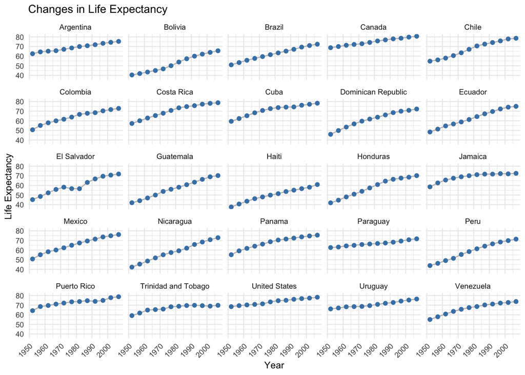

```r
# enhanced theme
ggplot(gap_americas, aes(x=year, y = lifeExp)) +
  geom_line(color="grey") +
  geom_point(color="steelblue") +
  facet_wrap(~country, ncol = 5) +
  theme_minimal(base_size = 9) +
  theme(axis.text.x = element_text(angle = 45,
                                   hjust = 1)) +
  labs(title = "Changes in Life Expectancy",
       x = "Year",
       y = "Life Expectancy")
```

# 9 Summary

Linegraphs, just like scatterplots, display the relationship between two numerical variables. When one of the two variables represents time, a linegraph can be a more effective method of displaying relationship. Therefore, it is preferred to use linegraphs over scatterplots when the variable on the *x*-axis (i.e., the explanatory variable) has an inherent ordering, such as some notion of time.

# Contributors

The following team members contributed to this lesson:

- [JOY VAZ](https://thegraphcourses.org/members/joy)  
  R Developer and Instructor, The Graph Network

  Loves doing science and teaching science.
- [ADMIN TEAM](https://thegraphnetwork.training/members/admin/)  
  GRAPH Courses Administration Team

  The GRAPH Courses team is building epidemiological training courses to enhance disease surveillance and data science for public health across the globe.

# References

Some material in this lesson was adapted from the following sources:

- Ismay, Chester, and Albert Y. Kim. 2022. *A ModernDive into R and the Tidyverse*. https://moderndive.com/.
- Kabacoff, Rob. 2020. *Data Visualization with R*. https://rkabacoff.github.io/datavis/.

This work is licensed under the [Creative Commons Attribution Share Alike](https://creativecommons.org/licenses/by-sa/4.0/) license.

[figure not shown]